# The following jupyter notebook contains a detailed analysis of the sales of different products of an online store during the festive month of October and November near Diwali

```python
# import python libraries


import numpy as np
import pandas as pd
import matplotlib.pyplot as plt # visualizing data
%matplotlib inline
import seaborn as sns
```

```python
# import csv file
df = pd.read_csv('Diwali Sales Data.csv', encoding= 'unicode_escape')
```

```python
df.shape
```

```
(11251, 15)
```

```python
df.head()
```

|  | User_ID | Cust_name | Product_ID | Gender | Age Group | Age | Marital_Status | State | Zone | Occupation | Product_Category | Orders | Amount | Status | unnamed1 |
| --- | --- | --- | --- | --- | --- | --- | --- | --- | --- | --- | --- | --- | --- | --- | --- |
| 0 | 1002903 | Sanskriti | P00125942 | F | 26-35 | 28 | 0 | Maharashtra | Western | Healthcare | Auto | 1 | 23952.0 | NaN | NaN |
| 1 | 1000732 | Kartik | P00110942 | F | 26-35 | 35 | 1 | Andhra Pradesh | Southern | Govt | Auto | 3 | 23934.0 | NaN | NaN |
| 2 | 1001990 | Bindu | P00118542 | F | 26-35 | 35 | 1 | Uttar Pradesh | Central | Automobile | Auto | 3 | 23924.0 | NaN | NaN |
| 3 | 1001425 | Sudevi | P00237842 | M | 0-17 | 16 | 0 | Karnataka | Southern | Construction | Auto | 2 | 23912.0 | NaN | NaN |
| 4 | 1000588 | Joni | P00057942 | M | 26-35 | 28 | 1 | Gujarat | Western | Food Processing | Auto | 2 | 23877.0 | NaN | NaN |

```python
df.info()
```

```
<class 'pandas.core.frame.DataFrame'>
RangeIndex: 11251 entries, 0 to 11250
Data columns (total 15 columns):
 #   Column            Non-Null Count  Dtype
---  ------            --------------  -----
 0   User_ID           11251 non-null  int64
 1   Cust_name         11251 non-null  object
 2   Product_ID        11251 non-null  object
 3   Gender            11251 non-null  object
 4   Age Group         11251 non-null  object
 5   Age               11251 non-null  int64
 6   Marital_Status    11251 non-null  int64
 7   State             11251 non-null  object
 8   Zone              11251 non-null  object
 9   Occupation        11251 non-null  object
 10  Product_Category  11251 non-null  object
 11  Orders            11251 non-null  int64
 12  Amount            11239 non-null  float64
 13  Status            0 non-null      float64
 14  unnamed1          0 non-null      float64
dtypes: float64(3), int64(4), object(8)
memory usage: 1.3+ MB
```

```python
#drop unrelated/blank columns
df.drop(['Status', 'unnamed1'], axis=1, inplace=True)
```

```python
#check for null values
pd.isnull(df).sum()
```

```
User_ID              0
Cust_name            0
Product_ID           0
Gender               0
Age Group            0
Age                  0
Marital_Status       0
State                0
Zone                 0
Occupation           0
Product_Category     0
Orders               0
Amount              12
dtype: int64
```

```python
# drop null values
df.dropna(inplace=True)
```

```python
# change data type
df['Amount'] = df['Amount'].astype('int')
```

```python
df['Amount'].dtypes
```

```
dtype('int32')
```

```python
df.columns
```

```
Index(['User_ID', 'Cust_name', 'Product_ID', 'Gender', 'Age Group', 'Age',
       'Marital_Status', 'State', 'Zone', 'Occupation', 'Product_Category',
       'Orders', 'Amount'],
      dtype='object')
```

```python
#rename column
df.rename(columns= {'Marital_Status':'Married(0/1)'})
```

|  | User_ID | Cust_name | Product_ID | Gender | Age Group | Age | Married(0/1) | State | Zone | Occupation | Product_Category | Orders | Amount |
| --- | --- | --- | --- | --- | --- | --- | --- | --- | --- | --- | --- | --- | --- |
| 0 | 1002903 | Sanskriti | P00125942 | F | 26-35 | 28 | 0 | Maharashtra | Western | Healthcare | Auto | 1 | 23952 |
| 1 | 1000732 | Kartik | P00110942 | F | 26-35 | 35 | 1 | Andhra Pradesh | Southern | Govt | Auto | 3 | 23934 |
| 2 | 1001990 | Bindu | P00118542 | F | 26-35 | 35 | 1 | Uttar Pradesh | Central | Automobile | Auto | 3 | 23924 |
| 3 | 1001425 | Sudevi | P00237842 | M | 0-17 | 16 | 0 | Karnataka | Southern | Construction | Auto | 2 | 23912 |
| 4 | 1000588 | Joni | P00057942 | M | 26-35 | 28 | 1 | Gujarat | Western | Food Processing | Auto | 2 | 23877 |
| ... | ... | ... | ... | ... | ... | ... | ... | ... | ... | ... | ... | ... | ... |
| 11246 | 1000695 | Manning | P00296942 | M | 18-25 | 19 | 1 | Maharashtra | Western | Chemical | Office | 4 | 370 |
| 11247 | 1004089 | Reichenbach | P00171342 | M | 26-35 | 33 | 0 | Haryana | Northern | Healthcare | Veterinary | 3 | 367 |
| 11248 | 1001209 | Oshin | P00201342 | F | 36-45 | 40 | 0 | Madhya Pradesh | Central | Textile | Office | 4 | 213 |
| 11249 | 1004023 | Noonan | P00059442 | M | 36-45 | 37 | 0 | Karnataka | Southern | Agriculture | Office | 3 | 206 |
| 11250 | 1002744 | Brumley | P00281742 | F | 18-25 | 19 | 0 | Maharashtra | Western | Healthcare | Office | 3 | 188 |

11239 rows × 13 columns

```python
# describe() method returns description of the data in the DataFrame (i.e. count, mean, std, etc)
df.describe()
```

[output not shown]

```python
# use describe() for specific columns
df[['Age', 'Orders', 'Amount']].describe()
```

|  | Age | Orders | Amount |
| --- | --- | --- | --- |
| count | 11239.000000 | 11239.000000 | 11239.000000 |
| mean | 35.410357 | 2.489634 | 9453.610553 |
| std | 12.753866 | 1.114967 | 5222.355168 |
| min | 12.000000 | 1.000000 | 188.000000 |
| 25% | 27.000000 | 2.000000 | 5443.000000 |
| 50% | 33.000000 | 2.000000 | 8109.000000 |
| 75% | 43.000000 | 3.000000 | 12675.000000 |
| max | 92.000000 | 4.000000 | 23952.000000 |

# Exploratory Data Analysis

### Gender

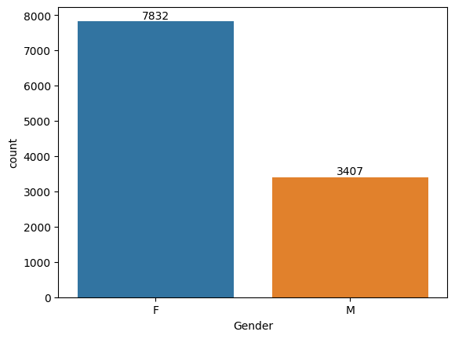

```python
# plotting a bar chart for Gender and it's count

ax = sns.countplot(x = 'Gender',data = df)

for bars in ax.containers:
    ax.bar_label(bars)
```

Out of the total orders around 70% orders are made by female customers and around 30% orders are made by male customers.

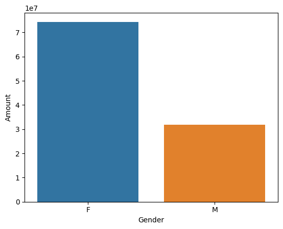

```python
# plotting a bar chart for gender vs total amount

sales_gen = df.groupby(['Gender'], as_index=False)['Amount'].sum().sort_values(by='Amount', ascending=False)

sns.barplot(x = 'Gender',y= 'Amount' ,data = sales_gen)
```

From above graphs we can see that most of the buyers are females and even the purchasing power of females are greater than men

### Age

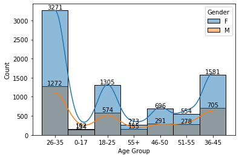

```python
ax = sns.histplot(data = df, x = 'Age Group', hue = 'Gender',kde=True)

for bars in ax.containers:
    ax.bar_label(bars)
```

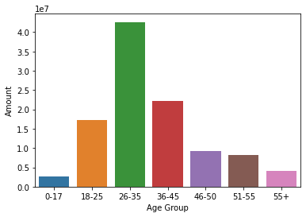

```python
# Total Amount vs Age Group
sales_age = df.groupby(['Age Group'], as_index=False)['Amount'].sum()

sns.barplot(x = 'Age Group',y= 'Amount' ,data = sales_age)
```

From above graphs we can see that most of the buyers are of age group between 26-35 yrs which are female

### State

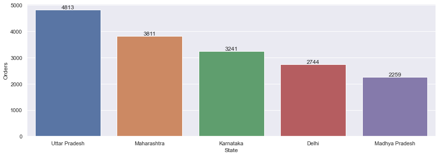

```python
# total number of orders from top 10 states

sales_state = df.groupby(['State'], as_index=False)['Orders'].sum().sort_values(by='Orders', ascending=False).head(5)

sns.set(rc={'figure.figsize':(15,5)})
ax1 = sns.barplot(data = sales_state, x = 'State',y= 'Orders')
for bars in ax1.containers:
    ax1.bar_label(bars)
```

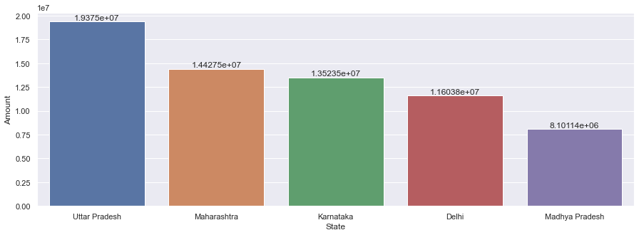

```python
# total amount/sales from top 10 states

sales_state = df.groupby(['State'], as_index=False)['Amount'].sum().sort_values(by='Amount', ascending=False).head(5)

sns.set(rc={'figure.figsize':(15,5)})
ax2 = sns.barplot(data = sales_state, x = 'State',y= 'Amount')
for bars in ax2.containers:
    ax2.bar_label(bars)
```

*From above graphs we can see that most of the orders & total sales/amount are from Uttar Pradesh, Maharashtra and Karnataka respectively*

### Marital Status

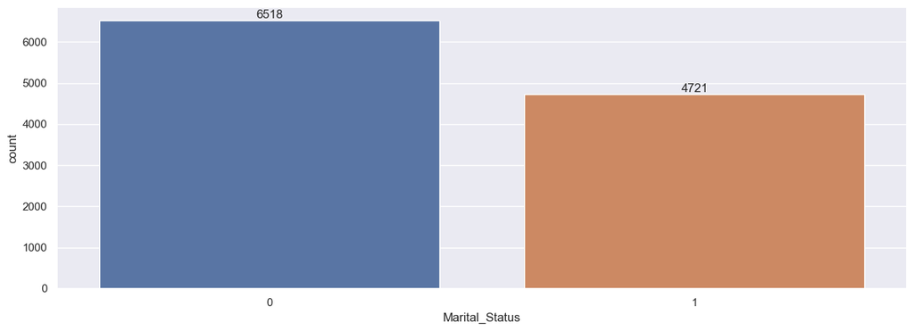

```python
ax = sns.countplot(data = df, x = 'Marital_Status')

sns.set(rc={'figure.figsize':(7,5)})
for bars in ax.containers:
    ax.bar_label(bars)
```

```python
df.corr()[['Amount']]
```

[output not shown]

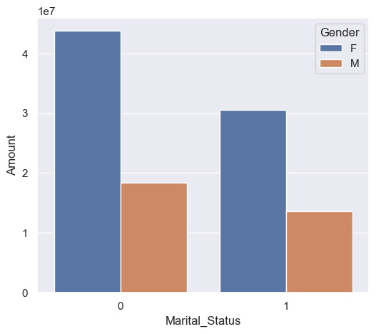

```python
sales_state = df.groupby(['Marital_Status', 'Gender'], as_index=False)['Amount'].sum().sort_values(by='Amount', ascending=False)

sns.set(rc={'figure.figsize':(6,5)})
sns.barplot(data = sales_state, x = 'Marital_Status',y= 'Amount', hue='Gender')
```

From the above graphs it is clear that most of our buyers are unmarried(0) and the highest amount made from unmarried female buyers specifically.

### Occupation

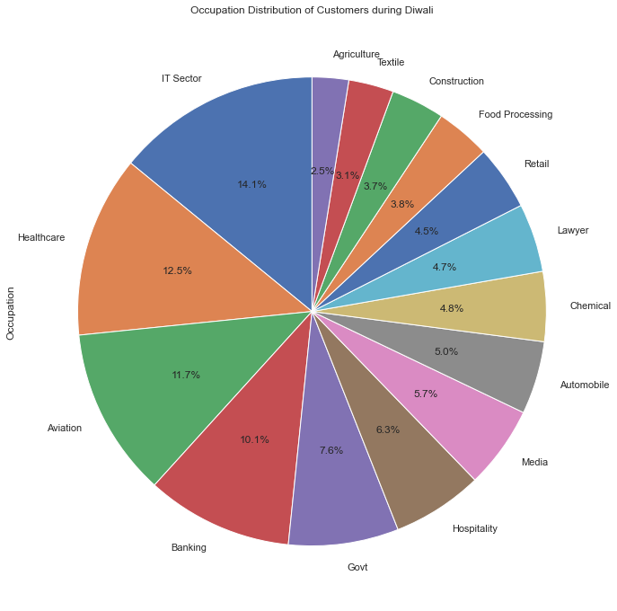

```python
plt.figure(figsize=(12, 12))
df['Occupation'].value_counts().plot.pie(autopct='%1.1f%%', startangle=90)
plt.title('Occupation Distribution of Customers during Diwali')
plt.show()
```

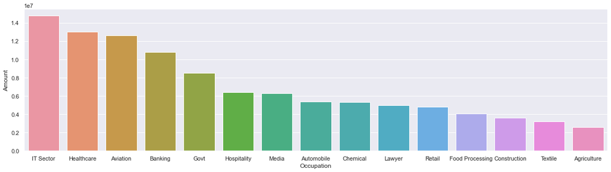

```python
sales_state = df.groupby(['Occupation'], as_index=False)['Amount'].sum().sort_values(by='Amount', ascending=False)

sns.set(rc={'figure.figsize':(20,5)})
sns.barplot(data = sales_state, x = 'Occupation',y= 'Amount')
```

*From above graphs we can see that most of the buyers are working in IT, Healthcare and Aviation sector*

### Product Category

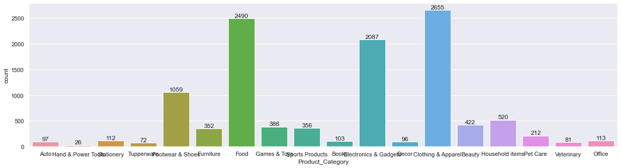

```python
sns.set(rc={'figure.figsize':(20,5)})

ax = sns.countplot(x = df['Product_Category'])

for bars in ax.containers:
    ax.bar_label(bars)
```

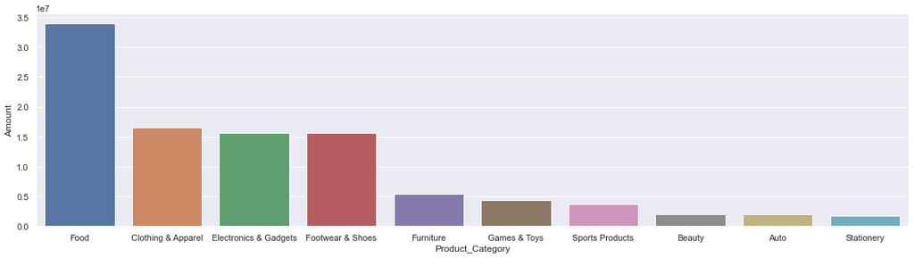

```python
sales_state = df.groupby(['Product_Category'], as_index=False)['Amount'].sum().sort_values(by='Amount', ascending=False).head(10)

sns.set(rc={'figure.figsize':(20,5)})
sns.barplot(data = sales_state, x = 'Product_Category',y= 'Amount')
```

We see something very interesting in the above charts although the highest number of orders are in Clothing and apparel, food and electronics respectively the same order isnt followed when the amount is considered. Highest amount is generated from Food, clothing and electronics

# Some Bivariate analyses

```python
ctab2 = pd.crosstab(df['State'], df['Occupation'])
ctab2
```

| Occupation State | Agriculture | Automobile | Aviation | Banking | Chemical | Construction | Food Processing | Govt | Healthcare | Hospitality | IT Sector | Lawyer | Media | Retail | Textile |
| --- | --- | --- | --- | --- | --- | --- | --- | --- | --- | --- | --- | --- | --- | --- | --- |
| Andhra Pradesh | 19 | 39 | 99 | 82 | 38 | 24 | 28 | 70 | 114 | 48 | 114 | 42 | 49 | 27 | 18 |
| Bihar | 10 | 19 | 37 | 38 | 25 | 18 | 16 | 21 | 59 | 31 | 64 | 23 | 35 | 26 | 12 |
| Delhi | 37 | 47 | 131 | 108 | 57 | 39 | 36 | 97 | 131 | 67 | 173 | 51 | 52 | 44 | 34 |
| Gujarat | 12 | 21 | 65 | 35 | 20 | 15 | 24 | 29 | 48 | 23 | 51 | 28 | 23 | 22 | 11 |
| Haryana | 12 | 28 | 55 | 51 | 17 | 17 | 16 | 25 | 60 | 24 | 67 | 17 | 32 | 16 | 15 |
| Himachal Pradesh | 17 | 31 | 53 | 64 | 27 | 28 | 27 | 48 | 80 | 43 | 77 | 25 | 30 | 32 | 26 |
| Jharkhand | 7 | 24 | 43 | 50 | 22 | 17 | 23 | 36 | 38 | 24 | 46 | 9 | 14 | 17 | 10 |
| Karnataka | 39 | 63 | 153 | 138 | 66 | 45 | 47 | 94 | 155 | 81 | 176 | 62 | 68 | 68 | 49 |
| Kerala | 11 | 21 | 57 | 50 | 18 | 19 | 20 | 39 | 58 | 28 | 57 | 20 | 19 | 20 | 16 |
| Madhya Pradesh | 22 | 42 | 102 | 81 | 43 | 29 | 39 | 89 | 116 | 60 | 142 | 37 | 44 | 41 | 34 |
| Maharashtra | 29 | 82 | 190 | 166 | 71 | 52 | 46 | 110 | 198 | 89 | 218 | 82 | 94 | 62 | 36 |
| Punjab | 3 | 11 | 24 | 24 | 8 | 12 | 4 | 19 | 25 | 10 | 27 | 5 | 10 | 8 | 10 |
| Rajasthan | 4 | 15 | 22 | 22 | 8 | 7 | 16 | 19 | 24 | 24 | 34 | 6 | 8 | 7 | 15 |
| Telangana | 1 | 12 | 11 | 13 | 4 | 4 | 5 | 7 | 17 | 8 | 16 | 6 | 6 | 9 | 6 |
| Uttar Pradesh | 52 | 94 | 241 | 197 | 100 | 78 | 65 | 124 | 248 | 114 | 279 | 104 | 120 | 83 | 45 |
| Uttarakhand | 8 | 16 | 27 | 18 | 17 | 10 | 11 | 27 | 37 | 29 | 42 | 14 | 33 | 19 | 12 |

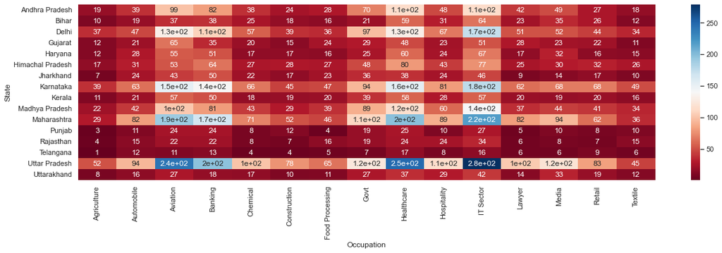

```python
sns.heatmap(ctab2, annot=True, cmap = 'RdBu')
```

From the above heatmap we can understand the regionwise occupation of our buyers.

```python
ctab = pd.crosstab(df['State'], df['Product_Category'])
ctab
```

| Product_Category State | Auto | Beauty | Books | Clothing & Apparel | Decor | Electronics & Gadgets | Food | Footwear & Shoes | Furniture | Games & Toys | Hand & Power Tools | Household items | Office | Pet Care | Sports Products | Stationery | Tupperware | Veterinary |
| --- | --- | --- | --- | --- | --- | --- | --- | --- | --- | --- | --- | --- | --- | --- | --- | --- | --- | --- |
| Andhra Pradesh | 57 | 40 | 4 | 159 | 0 | 277 | 154 | 20 | 17 | 25 | 6 | 11 | 2 | 10 | 25 | 1 | 3 | 0 |
| Bihar | 1 | 2 | 1 | 140 | 0 | 95 | 113 | 10 | 14 | 13 | 0 | 11 | 3 | 10 | 17 | 1 | 3 | 0 |
| Delhi | 3 | 46 | 7 | 129 | 0 | 95 | 194 | 335 | 3 | 19 | 10 | 82 | 62 | 7 | 11 | 74 | 3 | 24 |
| Gujarat | 1 | 3 | 5 | 113 | 0 | 106 | 102 | 10 | 18 | 19 | 0 | 5 | 2 | 9 | 24 | 1 | 9 | 0 |
| Haryana | 0 | 4 | 1 | 123 | 0 | 105 | 120 | 9 | 15 | 17 | 0 | 7 | 2 | 13 | 25 | 2 | 5 | 4 |
| Himachal Pradesh | 3 | 3 | 9 | 240 | 0 | 167 | 53 | 14 | 23 | 38 | 1 | 8 | 2 | 20 | 23 | 3 | 1 | 0 |
| Jharkhand | 3 | 1 | 1 | 148 | 0 | 124 | 53 | 9 | 6 | 16 | 0 | 4 | 2 | 6 | 4 | 0 | 0 | 3 |
| Karnataka | 3 | 15 | 39 | 220 | 0 | 71 | 302 | 338 | 23 | 55 | 0 | 137 | 5 | 34 | 54 | 3 | 5 | 0 |
| Kerala | 2 | 7 | 4 | 182 | 0 | 110 | 48 | 10 | 42 | 5 | 0 | 23 | 3 | 0 | 2 | 1 | 13 | 1 |
| Madhya Pradesh | 3 | 208 | 4 | 138 | 0 | 130 | 209 | 84 | 32 | 19 | 1 | 19 | 8 | 9 | 22 | 2 | 3 | 30 |
| Maharashtra | 6 | 37 | 8 | 327 | 28 | 191 | 480 | 55 | 49 | 72 | 2 | 121 | 11 | 28 | 77 | 15 | 13 | 5 |
| Punjab | 1 | 2 | 1 | 37 | 0 | 126 | 17 | 3 | 1 | 0 | 2 | 7 | 1 | 1 | 0 | 0 | 0 | 1 |
| Rajasthan | 0 | 1 | 2 | 35 | 0 | 134 | 23 | 4 | 12 | 5 | 0 | 9 | 0 | 3 | 1 | 0 | 0 | 2 |
| Telangana | 0 | 0 | 0 | 17 | 0 | 59 | 38 | 3 | 0 | 2 | 1 | 1 | 1 | 1 | 2 | 0 | 0 | 0 |
| Uttar Pradesh | 13 | 52 | 16 | 490 | 68 | 224 | 567 | 146 | 73 | 76 | 3 | 65 | 8 | 46 | 66 | 8 | 12 | 11 |
| Uttarakhand | 1 | 1 | 1 | 157 | 0 | 73 | 17 | 9 | 24 | 5 | 0 | 10 | 1 | 15 | 3 | 1 | 2 | 0 |

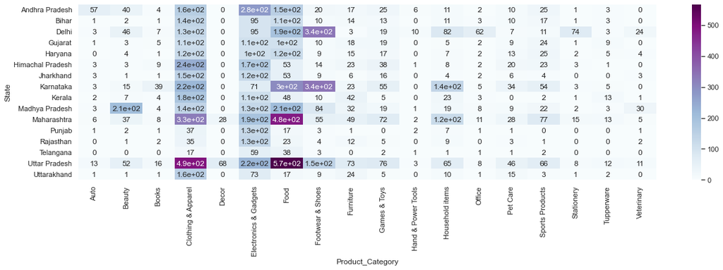

```python
sns.heatmap(ctab, annot=True, cmap='BuPu')
```

The above heatmap helps us understand the regionwise sales of the different product categories.

## Conclusion:

1) Targeted Marketing:

Given that most buyers are females, consider tailoring your marketing campaigns to cater to the preferences and needs of female customers. This might involve featuring products that are popular among women or running promotions specifically targeted at them.

2) Customer Engagement:

Since unmarried females make up a significant portion of your customer base, you could focus on engagement strategies that resonate with this demographic. For example, creating content related to lifestyle, fashion, and personal interests might be effective.

3) Age-Specific Promotions:

With the age group of 26-35 being the most active in terms of orders, you can design promotions or loyalty programs that appeal to this age bracket. Consider offering discounts on products that are popular among this age group.

4) Geographic Expansion or Targeted Campaigns:

As you've identified the states with the highest number of orders (Uttar Pradesh, Maharashtra, and Karnataka), you may want to consider targeted marketing efforts in these regions. This could involve location-specific promotions, advertising, or partnerships.

5) Industry-Specific Campaigns:

Recognizing that most of your buyers work in IT, Healthcare, and Aviation, you might customize your marketing efforts to align with the interests and needs of professionals in these industries. Specialized promotions or product bundles could be created to appeal to these specific customer segments.

6) Category-Specific Strategies:

Since food, clothing and apparel, electronics and gadgets, footwear and shoes are the most ordered categories, you can focus on optimizing your inventory and marketing efforts for these categories. Consider introducing new products, offering bundle deals, or running promotions to boost sales in these areas.

7) Customer Feedback:

Engage with your customers through surveys or feedback forms to gather more insights. Understanding why they prefer certain products or categories can help you refine your offerings and improve customer satisfaction.

# Some focused order driven conclusions regarding our analysis

1) Unmarried women age group 26-35 yrs from UP, Maharastra and Karnataka working in IT, Healthcare and Aviation are more likely to buy products from Food, Clothing and Electronics category

2) From our heatmaps we can conclude our major sources of orders:

1. Food industry in Uttar Pradesh and Maharashtra.
2. Clothing and apparel in Uttar Pradesh and Maharashtra.
3. Electronics and gadgets in Andhra pradesh.
4. Footwear and shoes in Karnataka and Delhi.

3) We can also boost some of the following:

1. Beauty products industry in Madhya Pradesh.
2. Household items industry in Maharashtra and Karnataka.

Thank you.